# Pandas 案例讲解

现在我们有一组从2006年到2016年1000部最流行的电影数据，我们想要了解下面的3个问题：

- 问题1：我们想知道这些电影数据中评分的平均分，导演的人数等信息，我们应该怎么获取？
- 问题2：对于这一组电影数据，如果我们想获取rating的分布情况，应该如何呈现数据？
- 问题3：对于这一组电影数据，如果我们希望统计电影分类(genre)的情况，应该如何处理数据？

我们首先导入包和数据:

```python
import pandas as pd
import numpy as np
from matplotlib import pyplot as plt

# 读取文件
movie_data = pd.read_csv('../data/IMDB-Movie-Data.csv', encoding='gbk')
movie_data.head()
```

[output not shown]

## 问题1

我们想知道这些电影数据中评分的平均分，导演的人数等信息，我们应该怎么获取？

- 得出评分的平均分

```python
# 运用mean函数计算平均分
movie_data['Rating'].mean()
```

```
6.723200000000003
```

- 得出导演人数信息： 导演可能会有重复，所以需要求出唯一值

```python
# 使用np.unique()求出导演这一列的唯一值
np.unique(movie_data['Director']).shape[0]
```

```
644
```

## 问题2

对于这一组电影数据，如果我们想获取Rating的分布情况，应该如何呈现数据？

- 我们可以使用pandas内置的画图plot函数进行绘制

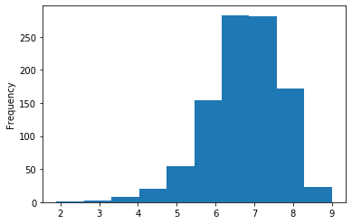

```python
# 使用pandas的plot函数
movie_data['Rating'].plot(kind='hist')
```

- 现在我们觉得x轴的刻度不太准确，想要更精确一些。

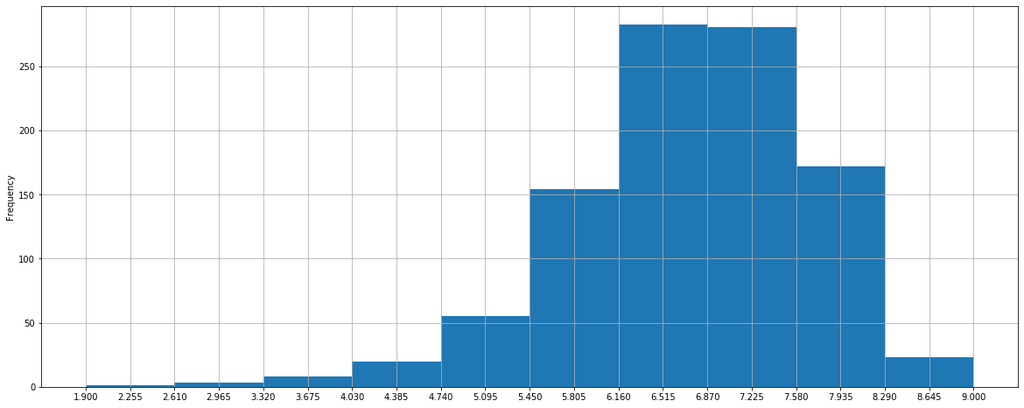

```python
# 求出Rating的最大值和最小值
max_rating = movie_data['Rating'].max()
min_rating = movie_data['Rating'].min()

# 生成刻度列表
xticks = np.linspace(min_rating, max_rating, num=21)

# 再添加网格
movie_data['Rating'].plot(kind='hist', xticks=xticks,
                          grid=True, figsize=(20, 8))
```

## 问题3

对于这一组电影数据，如果我们希望统计电影分类(genre)的情况，应该如何处理数据？

- 思路
  - 1. 首先我们观察数据，一个电影会包含多个电影分类，所以我们需要进行字符串分割，把所有的电影种类统计出来。
  - 1. 然后，我们可以建立一个全为0的DataFrame，列索引设为统计出来的电影种类，每一行代表一个电影，设为temp_df。
  - 1. 遍历每一个电影，在temp_df把电影出现的种类标为1。
  - 1. 进行求和，即可得出结果。
- 1. 统计所有的电影种类

```python
# 对'Genre'列进行字符串分割，用一个temp_list保存临时变量
temp_list = [i.split(',') for i in movie_data['Genre']]
temp_list[:10]
```

```
[['Action', 'Adventure', 'Sci-Fi'],
 ['Adventure', 'Mystery', 'Sci-Fi'],
 ['Horror', 'Thriller'],
 ['Animation', 'Comedy', 'Family'],
 ['Action', 'Adventure', 'Fantasy'],
 ['Action', 'Adventure', 'Fantasy'],
 ['Comedy', 'Drama', 'Music'],
 ['Comedy'],
 ['Action', 'Adventure', 'Biography'],
 ['Adventure', 'Drama', 'Romance']]
```

```python
# 获取电影的分类
genre_list = np.unique([i for j in temp_list for i in j])
genre_list
```

```
array(['Action', 'Adventure', 'Animation', 'Biography', 'Comedy', 'Crime',
       'Drama', 'Family', 'Fantasy', 'History', 'Horror', 'Music',
       'Musical', 'Mystery', 'Romance', 'Sci-Fi', 'Sport', 'Thriller',
       'War', 'Western'], dtype='<U9')
```

- 2.新建一个全为0的DataFrame，用于后面的遍历电影种类，记录增量

```python
# 新建一个全为0的DataFrame
temp_df = pd.DataFrame(
    np.zeros([movie_data.shape[0], genre_list.shape[0]]), columns=genre_list)
temp_df
```

|  | Action | Adventure | Animation | Biography | Comedy | Crime | Drama | Family | Fantasy | History | Horror | Music | Musical | Mystery | Romance | Sci-Fi | Sport | Thriller | War | Western |
| --- | --- | --- | --- | --- | --- | --- | --- | --- | --- | --- | --- | --- | --- | --- | --- | --- | --- | --- | --- | --- |
| 0 | 0.0 | 0.0 | 0.0 | 0.0 | 0.0 | 0.0 | 0.0 | 0.0 | 0.0 | 0.0 | 0.0 | 0.0 | 0.0 | 0.0 | 0.0 | 0.0 | 0.0 | 0.0 | 0.0 | 0.0 |
| 1 | 0.0 | 0.0 | 0.0 | 0.0 | 0.0 | 0.0 | 0.0 | 0.0 | 0.0 | 0.0 | 0.0 | 0.0 | 0.0 | 0.0 | 0.0 | 0.0 | 0.0 | 0.0 | 0.0 | 0.0 |
| 2 | 0.0 | 0.0 | 0.0 | 0.0 | 0.0 | 0.0 | 0.0 | 0.0 | 0.0 | 0.0 | 0.0 | 0.0 | 0.0 | 0.0 | 0.0 | 0.0 | 0.0 | 0.0 | 0.0 | 0.0 |
| 3 | 0.0 | 0.0 | 0.0 | 0.0 | 0.0 | 0.0 | 0.0 | 0.0 | 0.0 | 0.0 | 0.0 | 0.0 | 0.0 | 0.0 | 0.0 | 0.0 | 0.0 | 0.0 | 0.0 | 0.0 |
| 4 | 0.0 | 0.0 | 0.0 | 0.0 | 0.0 | 0.0 | 0.0 | 0.0 | 0.0 | 0.0 | 0.0 | 0.0 | 0.0 | 0.0 | 0.0 | 0.0 | 0.0 | 0.0 | 0.0 | 0.0 |
| ... | ... | ... | ... | ... | ... | ... | ... | ... | ... | ... | ... | ... | ... | ... | ... | ... | ... | ... | ... | ... |
| 995 | 0.0 | 0.0 | 0.0 | 0.0 | 0.0 | 0.0 | 0.0 | 0.0 | 0.0 | 0.0 | 0.0 | 0.0 | 0.0 | 0.0 | 0.0 | 0.0 | 0.0 | 0.0 | 0.0 | 0.0 |
| 996 | 0.0 | 0.0 | 0.0 | 0.0 | 0.0 | 0.0 | 0.0 | 0.0 | 0.0 | 0.0 | 0.0 | 0.0 | 0.0 | 0.0 | 0.0 | 0.0 | 0.0 | 0.0 | 0.0 | 0.0 |
| 997 | 0.0 | 0.0 | 0.0 | 0.0 | 0.0 | 0.0 | 0.0 | 0.0 | 0.0 | 0.0 | 0.0 | 0.0 | 0.0 | 0.0 | 0.0 | 0.0 | 0.0 | 0.0 | 0.0 | 0.0 |
| 998 | 0.0 | 0.0 | 0.0 | 0.0 | 0.0 | 0.0 | 0.0 | 0.0 | 0.0 | 0.0 | 0.0 | 0.0 | 0.0 | 0.0 | 0.0 | 0.0 | 0.0 | 0.0 | 0.0 | 0.0 |
| 999 | 0.0 | 0.0 | 0.0 | 0.0 | 0.0 | 0.0 | 0.0 | 0.0 | 0.0 | 0.0 | 0.0 | 0.0 | 0.0 | 0.0 | 0.0 | 0.0 | 0.0 | 0.0 | 0.0 | 0.0 |

1000 rows × 20 columns

- 3.遍历每一个电影，在temp_df把电影出现的种类标为1

```python
# 使用df.iloc对temp_df进行索引赋值
for i in range(movie_data.shape[0]):
    temp_df.iloc[i, temp_df.columns.get_indexer(temp_list[i])] = 1

temp_df.head()
```

|  | Action | Adventure | Animation | Biography | Comedy | Crime | Drama | Family | Fantasy | History | Horror | Music | Musical | Mystery | Romance | Sci-Fi | Sport | Thriller | War | Western |
| --- | --- | --- | --- | --- | --- | --- | --- | --- | --- | --- | --- | --- | --- | --- | --- | --- | --- | --- | --- | --- |
| 0 | 1.0 | 1.0 | 0.0 | 0.0 | 0.0 | 0.0 | 0.0 | 0.0 | 0.0 | 0.0 | 0.0 | 0.0 | 0.0 | 0.0 | 0.0 | 1.0 | 0.0 | 0.0 | 0.0 | 0.0 |
| 1 | 0.0 | 1.0 | 0.0 | 0.0 | 0.0 | 0.0 | 0.0 | 0.0 | 0.0 | 0.0 | 0.0 | 0.0 | 0.0 | 1.0 | 0.0 | 1.0 | 0.0 | 0.0 | 0.0 | 0.0 |
| 2 | 0.0 | 0.0 | 0.0 | 0.0 | 0.0 | 0.0 | 0.0 | 0.0 | 0.0 | 0.0 | 1.0 | 0.0 | 0.0 | 0.0 | 0.0 | 0.0 | 0.0 | 1.0 | 0.0 | 0.0 |
| 3 | 0.0 | 0.0 | 1.0 | 0.0 | 1.0 | 0.0 | 0.0 | 1.0 | 0.0 | 0.0 | 0.0 | 0.0 | 0.0 | 0.0 | 0.0 | 0.0 | 0.0 | 0.0 | 0.0 | 0.0 |
| 4 | 1.0 | 1.0 | 0.0 | 0.0 | 0.0 | 0.0 | 0.0 | 0.0 | 1.0 | 0.0 | 0.0 | 0.0 | 0.0 | 0.0 | 0.0 | 0.0 | 0.0 | 0.0 | 0.0 | 0.0 |

- 1. 进行求和并绘图展示

```python
# 进行求和并排序
genre_sum = temp_df.sum().sort_values(ascending=False)
genre_sum
```

```
Drama        513.0
Action       303.0
Comedy       279.0
Adventure    259.0
Thriller     195.0
Crime        150.0
Romance      141.0
Sci-Fi       120.0
Horror       119.0
Mystery      106.0
Fantasy      101.0
Biography     81.0
Family        51.0
Animation     49.0
History       29.0
Sport         18.0
Music         16.0
War           13.0
Western        7.0
Musical        5.0
dtype: float64
```

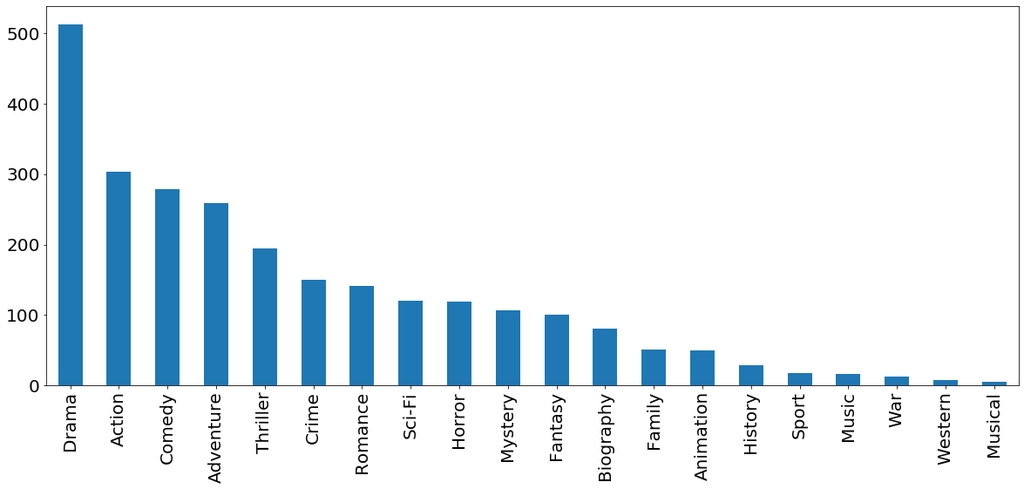

```python
# 进行画图
genre_sum.plot(kind='bar', figsize=(20, 8), fontsize=20)
```